# Data manipulation in R

Originally prepared by David Nipperess, modified by Matthew Kosnik

28 October 2017

# Preliminary 1: Set up workspace

- Set up a new project in R Studio
- Where is your working directory?
- Are the files you need in your working directory?

# Preliminary 2: Data objects in R

This should all be review from yesterday, but it is a good review as. it is important.

## Define a vector of the numerical values 1 to 27 and assign to an object called x

```r
x <- 1:27
x
```

```
##  [1]  1  2  3  4  5  6  7  8  9 10 11 12 13 14 15 16 17 18 19 20 21 22 23
## [24] 24 25 26 27
```

## Define a matrix (assign to y) with 9 rows and 3 columns using the data in x

```r
y <- matrix(data=x, nrow=9, ncol=3)
y
```

```
##       [,1] [,2] [,3]
##  [1,]    1   10   19
##  [2,]    2   11   20
##  [3,]    3   12   21
##  [4,]    4   13   22
##  [5,]    5   14   23
##  [6,]    6   15   24
##  [7,]    7   16   25
##  [8,]    8   17   26
##  [9,]    9   18   27
```

## Extract a vector from y using the numerical indices in x

```r
y[x]  # referencing an object with another object
```

```
##  [1]  1  2  3  4  5  6  7  8  9 10 11 12 13 14 15 16 17 18 19 20 21 22 23
## [24] 24 25 26 27
```

## Define a 3-dimensional array (assign to z) with 3 rows, 3 columns and 3 layers, using the data in x

```r
z <- array(data=x,dim=c(3,3,3))
z
```

```
## , , 1
##
##      [,1] [,2] [,3]
## [1,]    1    4    7
## [2,]    2    5    8
## [3,]    3    6    9
##
## , , 2
##
##      [,1] [,2] [,3]
## [1,]   10   13   16
## [2,]   11   14   17
## [3,]   12   15   18
##
## , , 3
##
##      [,1] [,2] [,3]
## [1,]   19   22   25
## [2,]   20   23   26
## [3,]   21   24   27
```

```r
z[1,,]
```

```
##      [,1] [,2] [,3]
## [1,]    1   10   19
## [2,]    4   13   22
## [3,]    7   16   25
```

```r
z[x]
```

```
##  [1]  1  2  3  4  5  6  7  8  9 10 11 12 13 14 15 16 17 18 19 20 21 22 23
## [24] 24 25 26 27
```

## Extract a reversed vector from z using x

```r
z[rev(x)]
```

```
##  [1] 27 26 25 24 23 22 21 20 19 18 17 16 15 14 13 12 11 10  9  8  7  6  5
## [24]  4  3  2  1
```

**QUESTION**: What does the function rev() do?

**QUESTION**: How can you find out?

Browse the datasets available in R, find Edgar Anderson’s Iris data and load it as a dataframe

# 50 replicate measurements for each of 3 species of Iris

```r
data()
data(iris)
```

**QUESTION**: what does head() do?

```r
head(iris)
```

```
##   Sepal.Length Sepal.Width Petal.Length Petal.Width Species
## 1          5.1         3.5          1.4         0.2  setosa
## 2          4.9         3.0          1.4         0.2  setosa
## 3          4.7         3.2          1.3         0.2  setosa
## 4          4.6         3.1          1.5         0.2  setosa
## 5          5.0         3.6          1.4         0.2  setosa
## 6          5.4         3.9          1.7         0.4  setosa
```

**QUESTION**: what does dim() do?

```r
dim(iris)
```

```
## [1] 150   5
```

**QUESTION**: what does mode() do?

```r
mode(iris)
```

```
## [1] "list"
```

### Use as.matrix() to convert the iris dataset to a matrix and use head() & mode() to check the data

```r
iris2 <- as.matrix(iris)
head(iris2)     # Question: why quotes?
```

```
##      Sepal.Length Sepal.Width Petal.Length Petal.Width Species
## [1,] "5.1"        "3.5"       "1.4"        "0.2"       "setosa"
## [2,] "4.9"        "3.0"       "1.4"        "0.2"       "setosa"
## [3,] "4.7"        "3.2"       "1.3"        "0.2"       "setosa"
## [4,] "4.6"        "3.1"       "1.5"        "0.2"       "setosa"
## [5,] "5.0"        "3.6"       "1.4"        "0.2"       "setosa"
## [6,] "5.4"        "3.9"       "1.7"        "0.4"       "setosa"
```

```r
mode(iris2)     # Question: character?
```

```
## [1] "character"
```

**QUESTION**: what happens when you try to take the mean of iris2[,‘Sepal.Length’]

```r
mean(iris2[,'Sepal.Length'])        # Problem...
```

```
## [1] NA
```

### Use as.matrix() to convert only the numeric columns of iris dataset. Check the data.

```r
iris3 <- as.matrix(iris[,1:4])
head(iris3)
```

```
##      Sepal.Length Sepal.Width Petal.Length Petal.Width
## [1,]          5.1         3.5          1.4         0.2
## [2,]          4.9         3.0          1.4         0.2
## [3,]          4.7         3.2          1.3         0.2
## [4,]          4.6         3.1          1.5         0.2
## [5,]          5.0         3.6          1.4         0.2
## [6,]          5.4         3.9          1.7         0.4
```

```r
mode(iris3)
```

```
## [1] "numeric"
```

**QUESTION**: what is the mean sepal length?

```r
mean(iris3[,'Sepal.Length'])                # Answer...
```

```
## [1] 5.843333
```

**QUESTION**: how might we work around this issue, hint: `as.numeric()`?

```r
mean(as.numeric(iris2[,'Sepal.Length']))    # Work around.
```

```
## [1] 5.843333
```

## Using matrices instead of data frames

When data is all numbers (except for row and column names), I normally use matrices rather than dataframes if you have row names in your data file, and you want to convert to a matrix, you will need to specify which column has the row names (see the `row.names` argument in the `read.table` function)

## Exercise 1: Reading data

Use the `read.table` (and related functions) to read in datafiles: “carbonateMetaData.txt”, “carbonateMassData.csv”, “carbonateSynonomy.csv”

**ABOUT THESE DATA**: These are sediment samples from Heron Reef. Students were instructed to sort the sediment into the organisms that created it, and to report the weight of each taxonomic group in grams. “carbonateMassData.csv” contains the mass by taxonomic group data. “carbonateMetaData.txt” contains metadata - information aboit the sample provided to the students. “carbonateSynonomy.csv” is a list of spelling corrections and synonomies that I use to harmonise the data without changing the original data.

- **TIP**: always inspect your data BEFORE attempting to import into R

Use `read.table()` to read carbonateMetaData.txt. `read.table()` is the generic function

```r
cMeta <- read.table("./data/carbonateMetaData.txt", header=TRUE, sep="\t", as.is=TRUE)
```

`read.delim()` is `read.table()`, but will default values set for tab-delimited files.Use it to read `./data/carbonateMetaData.txt`

```r
cMeta <- read.delim("./data/carbonateMetaData.txt")
```

`read.table()` is the generic function and can read csv files…

```r
cMass <- read.table('./data/carbonateMassData.csv', header = TRUE, sep = ",", quote = "\"", fill = TRUE, comment.char = "", as.is=TRUE)
```

`read.csv()` is `read.table()`, but will default values set for csv files.Use it to read: `./data/carbonateSynonomy.csv`

```r
cSyn <-read.csv('./data/carbonateSynonomy.csv', skip=5, as.is=TRUE)
```

**QUESTION**: What does ‘as.is’ do, and why might we want to use it?

**QUESTION**: What does ‘skip’ do, and why might we want to use it?

- **TIP**: always inspect your data AFTER importing to make sure you have imported it correctly…

**QUESTION**: What do each of these functions: head(), tail(), nrow(), dims(), summary() do?

```r
head(cMass)
```

```
##   sample          taxon  mass
## 1    E01   Hamelida sp.  5.85
## 2    E01 Coraline algae 57.88
## 3    E01   Foraminifera  1.32
## 4    E01     Alcyonacea  0.88
## 5    E01   Scleractinia  8.67
## 6    E01     Tube worms  6.39
```

```r
tail(cMeta)
```

```
##     ID core layer fraction replcate mass
## 36 E36  124   264       98        4  130
## 37 E37  124   264       98        5  121
## 38 E38  124   264       98        6  121
## 39 E39  124   264       98        7  128
## 40 E40  124   264       98        8  126
## 41 E41   83   244      575        8  126
```

```r
nrow(cMeta)
```

```
## [1] 41
```

```r
summary(cMass)
```

```
##     sample             taxon                mass
##  Length:378         Length:378         Min.   : 0.008
##  Class :character   Class :character   1st Qu.: 1.372
##  Mode  :character   Mode  :character   Median : 4.218
##                                        Mean   :11.320
##                                        3rd Qu.:18.788
##                                        Max.   :68.398
```

## DIFFERENT WAYS REFERENCE COLUMNS, SHOULD ALL WORK

```r
cMass[,"mass"]
```

```
##   [1]  5.850 57.880  1.320  0.880  8.670  6.390  0.070 30.950 44.700  1.320
##  [11]  0.040  0.150 11.420 33.301 13.630  3.968  3.997  1.318  0.249  0.566
##  [21] 24.408 22.145  0.420  2.057 21.521  3.640 31.100 18.500  0.210  0.140
##  [31]  0.120 25.080  0.040  0.190  1.820  2.110 22.380 22.210 28.690  1.708
##  [41]  0.087  1.900 30.186 27.836  4.215  8.350 22.370 53.047  7.414 22.960
##  [51] 15.341  1.969  3.818  1.449 10.272  0.009  0.242 17.133  1.230  2.060
##  [61] 13.180 21.790 26.490  1.430  6.990  0.860  0.890  0.610  0.010  0.180
##  [71] 56.740 54.580 38.780 19.450  7.050  1.850  8.040  1.510  1.260  1.380
##  [81] 21.950  3.600 14.910  0.009  5.550  1.010  3.140 12.850  8.830  0.031
##  [91] 61.880 21.112  0.976 24.986  4.215 43.434  0.367  0.672 11.553 22.124
## [101]  5.702  4.940  1.520  6.566 17.331 21.478  0.241  1.413  0.486  0.564
## [111]  0.041  0.022 50.096 23.851  8.500 45.351  8.400  9.750 26.990 32.077
## [121]  4.750  1.050  0.315  0.046  0.923 17.132  9.175  5.585 46.044  1.020
## [131] 10.822  0.313  4.107  0.890  0.110 21.298 14.272  1.972  9.534 15.351
## [141]  1.244  1.245  3.101  0.119  2.607 14.642 39.750  0.350  0.700 16.360
```

[output cut: 23 more lines]

```r
cMass[["mass"]]
```

```
##   [1]  5.850 57.880  1.320  0.880  8.670  6.390  0.070 30.950 44.700  1.320
##  [11]  0.040  0.150 11.420 33.301 13.630  3.968  3.997  1.318  0.249  0.566
##  [21] 24.408 22.145  0.420  2.057 21.521  3.640 31.100 18.500  0.210  0.140
##  [31]  0.120 25.080  0.040  0.190  1.820  2.110 22.380 22.210 28.690  1.708
##  [41]  0.087  1.900 30.186 27.836  4.215  8.350 22.370 53.047  7.414 22.960
##  [51] 15.341  1.969  3.818  1.449 10.272  0.009  0.242 17.133  1.230  2.060
##  [61] 13.180 21.790 26.490  1.430  6.990  0.860  0.890  0.610  0.010  0.180
##  [71] 56.740 54.580 38.780 19.450  7.050  1.850  8.040  1.510  1.260  1.380
##  [81] 21.950  3.600 14.910  0.009  5.550  1.010  3.140 12.850  8.830  0.031
##  [91] 61.880 21.112  0.976 24.986  4.215 43.434  0.367  0.672 11.553 22.124
## [101]  5.702  4.940  1.520  6.566 17.331 21.478  0.241  1.413  0.486  0.564
## [111]  0.041  0.022 50.096 23.851  8.500 45.351  8.400  9.750 26.990 32.077
## [121]  4.750  1.050  0.315  0.046  0.923 17.132  9.175  5.585 46.044  1.020
## [131] 10.822  0.313  4.107  0.890  0.110 21.298 14.272  1.972  9.534 15.351
## [141]  1.244  1.245  3.101  0.119  2.607 14.642 39.750  0.350  0.700 16.360
```

[output cut: 23 more lines]

```r
cMass$mass
```

```
##   [1]  5.850 57.880  1.320  0.880  8.670  6.390  0.070 30.950 44.700  1.320
##  [11]  0.040  0.150 11.420 33.301 13.630  3.968  3.997  1.318  0.249  0.566
##  [21] 24.408 22.145  0.420  2.057 21.521  3.640 31.100 18.500  0.210  0.140
##  [31]  0.120 25.080  0.040  0.190  1.820  2.110 22.380 22.210 28.690  1.708
##  [41]  0.087  1.900 30.186 27.836  4.215  8.350 22.370 53.047  7.414 22.960
##  [51] 15.341  1.969  3.818  1.449 10.272  0.009  0.242 17.133  1.230  2.060
##  [61] 13.180 21.790 26.490  1.430  6.990  0.860  0.890  0.610  0.010  0.180
##  [71] 56.740 54.580 38.780 19.450  7.050  1.850  8.040  1.510  1.260  1.380
##  [81] 21.950  3.600 14.910  0.009  5.550  1.010  3.140 12.850  8.830  0.031
##  [91] 61.880 21.112  0.976 24.986  4.215 43.434  0.367  0.672 11.553 22.124
## [101]  5.702  4.940  1.520  6.566 17.331 21.478  0.241  1.413  0.486  0.564
## [111]  0.041  0.022 50.096 23.851  8.500 45.351  8.400  9.750 26.990 32.077
## [121]  4.750  1.050  0.315  0.046  0.923 17.132  9.175  5.585 46.044  1.020
## [131] 10.822  0.313  4.107  0.890  0.110 21.298 14.272  1.972  9.534 15.351
## [141]  1.244  1.245  3.101  0.119  2.607 14.642 39.750  0.350  0.700 16.360
```

[output cut: 23 more lines]

## Exercise 2: Subsetting data

**QUESTION**: How many taxon occurences have a mass > 25 (in data frame cMass)?

```r
cMass[(cMass$mass>25),]         # this lists, but does not count, the taxon occurences
```

```
##     sample                   taxon   mass
## 2      E01          Coraline algae 57.880
## 8      E01                Bivalvia 30.950
## 9      E01              Gastropoda 44.700
## 14     E03             Rough Coral 33.301
## 27     E04          Coraline Algae 31.100
## 32     E04              Gastropoda 25.080
## 39     E05                   Coral 28.690
## 43     E05                Bivalves 30.186
## 44     E05              Gastropoda 27.836
## 48     E06                   Coral 53.047
## 63     E07 Gastropods (Terebridae) 26.490
## 71     E07                 Residue 56.740
## 72     E08              Coral ect. 54.580
## 73     E08              Gastropods 38.780
```

[output cut: 45 more lines]

**QUESTION**: What does (cMass$mass>25) return?

```r
length(cMass$mass>25)
```

```
## [1] 378
```

**QUESTION**: Why is this not the answer we want?

```r
length(which(cMass$mass>25))
```

```
## [1] 59
```

**QUESTION**: Why is this the answer we want?

**QUESTION**: What does which() return?

```r
which(cMass$mass>25)
```

```
##  [1]   2   8   9  14  27  32  39  43  44  48  63  71  72  73  91  96 113
## [18] 116 119 120 129 147 156 159 163 165 174 181 213 214 215 224 225 226
## [35] 244 246 247 254 264 271 272 273 288 290 296 304 309 314 323 324 329
## [52] 330 342 343 344 356 357 372 378
```

**QUESTION**: How much carbonate is from taxon occurences having a mass > 25 (in data frame cMass)?

```r
sum(which(cMass$mass>25))                   # does not work as intended... what does which return?
```

```
## [1] 11461
```

```r
sum(cMass[which(cMass$mass>25),'mass'])     # this is the answer we want.
```

```
## [1] 2179.961
```

**QUESTION**: What is the average mass of Gastropoda in these samples?

```r
mean(cMass$mass[(cMass$taxon == 'Gastropoda')])     # is this what we want?
```

```
## [1] 14.437
```

LET’S DOUBLE CHECK THAT ALL THE “Gastropoda” will match “Gastropoda:

```r
unique(cMass$taxon)
```

```
##   [1] "Hamelida sp."               "Coraline algae"
##   [3] "Foraminifera"               "Alcyonacea"
##   [5] "Scleractinia"               "Tube worms"
##   [7] "Bryozoa"                    "Bivalvia"
##   [9] "Gastropoda"                 "Decapoda"
##  [11] "Cirripedia"                 "Echinodermata"
##  [13] "Residue"                    "Rough Coral"
##  [15] "Smooth Coral"               "Forams: Marginopera"
##  [17] "Forams: Halimeda"           "Worm Tubes"
##  [19] "Red Worm Tubes"             "Echinoderms"
##  [21] "Gastropods"                 "Bivalves"
##  [23] "Chiton"                     "Crab"
##  [25] "Hamelida"                   "Coraline Algae"
##  [27] "Soft coral"                 "Tube worm"
##  [29] "Echinoderm"                 "Scaphopod"
```

[output cut: 55 more lines]

```r
unique(sort(cMass$taxon))       # what do each of these functions do?
```

```
##   [1] "Abranda"                    "Alcyonacea"
##   [3] "Algae"                      "Algae: Halimeda"
##   [5] "Algal Coral"                "Anthozoa"
##   [7] "Bivalva"                    "bivalve"
##   [9] "Bivalve"                    "bivalve residue"
##  [11] "Bivalves"                   "Bivalves: full"
##  [13] "Bivalves: partial"          "bivalvia"
##  [15] "Bivalvia"                   "Bivlave"
##  [17] "Brachiopod"                 "Branching Coral"
##  [19] "Bryazoans"                  "bryozoa"
##  [21] "Bryozoa"                    "bryozoan"
##  [23] "Bryozoans"                  "Bryzoa"
##  [25] "Bryzoan"                    "Chitin"
##  [27] "Chiton"                     "Cirripedia"
##  [29] "coral"                      "Coral"
```

[output cut: 55 more lines]

A strict match is not what we want… We could manually list all the row numbers…

```r
cMass[c(9,21,32),]                  # but we would need to list all the rows with gastropod data
```

```
##    sample      taxon   mass
## 9     E01 Gastropoda 44.700
## 21    E03 Gastropods 24.408
## 32    E04 Gastropoda 25.080
```

```r
mean(cMass[c(9,21,32),'mass'])      # will work but painfully and inflexible.
```

```
## [1] 31.396
```

A more robust solution (we will get to an even better solution later)

```r
?grep
```

```r
grep("Gastropod", cMass$taxon, ignore.case=TRUE)
```

```
##  [1]   9  21  32  44  51  63  64  73  81  92 106 118 127 137 150 163 172
## [18] 173 190 193 194 198 199 200 204 205 206 208 210 215 227 237 246 256
## [35] 264 274 288 296 314 323 330 342 344 356 373
```

```r
cMass[grep("Gastropod", cMass$taxon, ignore.case=TRUE),]
```

```
##     sample                   taxon   mass
## 9      E01              Gastropoda 44.700
## 21     E03              Gastropods 24.408
## 32     E04              Gastropoda 25.080
## 44     E05              Gastropoda 27.836
## 51     E06              Gastropods 15.341
## 63     E07 Gastropods (Terebridae) 26.490
## 64     E07       Gastropods (Atys)  1.430
## 73     E08              Gastropods 38.780
## 81     E09              Gastropoda 21.950
## 92     E10              gastropoda 21.112
## 106    E11              Gastropods 21.478
## 118    E12              Gastropods  9.750
## 127    E14               gastropod  9.175
## 137    E14       gastropod residue 14.272
```

[output cut: 31 more lines]

Since we know taxon names are case insentitive…

```r
cMass$taxon <- tolower(cMass$taxon)
```

```r
mean(cMass$mass[grep("gastropod", cMass$taxon)])
```

```
## [1] 18.84989
```

### EXERCISE: what is the biggest bivalve mass?

**Hint**: `max()`,`grep()`

## Exercise 3: Aggregating data

Use `aggregate()` produce a table of the total idenfied mass from each sample

```
## starting httpd help server ... done
```

```r
( sampleMass <- aggregate(cMass$mass,by=list(cMass$sample),FUN=sum) )
```

```
##    Group.1       x
## 1      E01 169.640
## 2      E03 127.580
## 3      E04 127.540
## 4      E05 125.342
## 5      E06 133.654
## 6      E07 132.460
## 7      E08 133.900
## 8      E09 133.760
## 9      E10 129.439
## 10     E11 134.251
## 11     E12 138.152
## 12     E14 132.740
## 13     E15  47.843
## 14     E16 125.980
```

[output cut: 20 more lines]

```r
colnames(sampleMass) <- c('ID','massIdentified')
head(sampleMass)
```

```
##    ID massIdentified
## 1 E01        169.640
## 2 E03        127.580
## 3 E04        127.540
## 4 E05        125.342
## 5 E06        133.654
## 6 E07        132.460
```

Now we have a summary table tellling us how much sample they were able to identify You can aggregate multiple data columns at one time (using the same function).

## Exercise 4: Matching data

Since I know how much sample they had to start with - how much of sample did they identify?

```r
?merge
```

```r
( mergedSamples <- merge(cMeta,sampleMass) )        # What does the extra set of () do?
```

```
##     ID core layer fraction replcate  mass massIdentified
## 1  E01   71    90      122        1 169.7        169.640
## 2  E03   71    90      122        3 127.8        127.580
## 3  E04   71    90      122        4 126.8        127.540
## 4  E05   71    91      123        1 133.3        125.342
## 5  E06   71    91      123        2 133.8        133.654
## 6  E07   71    91      123        3 134.1        132.460
## 7  E08   71    91      123        4 133.9        133.900
## 8  E09   71    91      123        5 134.0        133.760
## 9  E10   83   244      575        1 133.8        129.439
## 10 E11   83   244      575        2 133.1        134.251
## 11 E12   83   244      575        3 133.0        138.152
## 12 E14   83   244      575        5 133.0        132.740
## 13 E15   83   244      575        6 133.0         47.843
## 14 E16   83   244      575        7 133.0        125.980
```

[output cut: 20 more lines]

Now we have the original sample mass and the identified sample mass in the same dataframe.

```r
mergedSamples$proID <- mergedSamples$massIdentified / mergedSamples$mass
```

Now we have the proportion of each sample identified, did big samples have less identified?

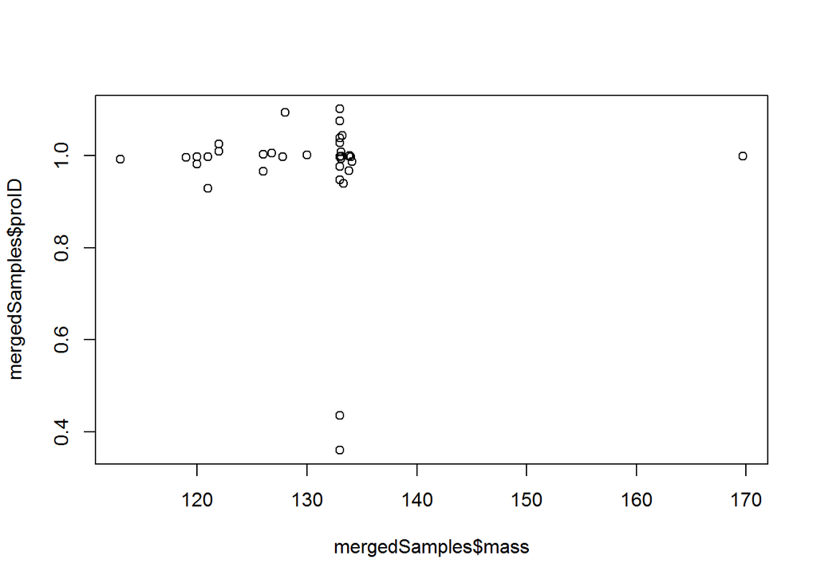

```r
plot(mergedSamples$proID ~ mergedSamples$mass)  #no, but we have found a couple of lazy students!
```

We can also use merge to clean up our names: Let’s clean up our names - are we missing any names from our synonomy list?

```r
cMass[!(cMass$taxon%in%cSyn$badName),]
```

```
##     sample         taxon   mass
## 4      E01    alcyonacea  0.880
## 5      E01  scleractinia  8.670
## 7      E01       bryozoa  0.070
## 8      E01      bivalvia 30.950
## 9      E01    gastropoda 44.700
## 10     E01      decapoda  1.320
## 11     E01    cirripedia  0.040
## 12     E01 echinodermata  0.150
## 13     E01       residue 11.420
## 25     E03       residue 21.521
## 31     E04  scleractinia  0.120
## 32     E04    gastropoda 25.080
## 36     E04      decapoda  2.110
## 37     E04      bivalvia 22.380
```

[output cut: 89 more lines]

```r
cMass[!((cMass$taxon%in%cSyn$badName)|(cMass$taxon%in%cSyn$taxonName)),]
```

```
##    sample      taxon mass
## 11    E01 cirripedia 0.04
```

```r
cMass2 <- merge(cMass,cSyn, by.x='taxon',by.y='badName')
head(cMass2)
```

```
##             taxon sample  mass      taxonName
## 1         abranda    E40 3.500       bivalvia
## 2         abranda    E35 2.702       bivalvia
## 3           algae    E06 7.414 corallineAlgae
## 4           algae    E33 6.151 corallineAlgae
## 5           algae    E38 6.112 corallineAlgae
## 6 algae: halimeda    E16 5.350       halimeda
```

```r
cMass2[(cMass2$taxon=='cirripedia'),]                   # here lies the biggest danger of merge
```

```
## [1] taxon     sample    mass      taxonName
## <0 rows> (or 0-length row.names)
```

```r
nrow(cMass)
```

```
## [1] 378
```

```r
nrow(cMass2)                                            # we lost data
```

```
## [1] 275
```

```r
cMass[cMass$sample =='E01',]                            # compare sample 1 in the oringal data
```

```
##    sample          taxon  mass
## 1     E01   hamelida sp.  5.85
## 2     E01 coraline algae 57.88
## 3     E01   foraminifera  1.32
## 4     E01     alcyonacea  0.88
## 5     E01   scleractinia  8.67
## 6     E01     tube worms  6.39
## 7     E01        bryozoa  0.07
## 8     E01       bivalvia 30.95
## 9     E01     gastropoda 44.70
## 10    E01       decapoda  1.32
## 11    E01     cirripedia  0.04
## 12    E01  echinodermata  0.15
## 13    E01        residue 11.42
```

```r
cMass2[cMass2$sample =='E01',]                          # compare sample 1 in the merged data
```

```
##              taxon sample  mass      taxonName
## 85  coraline algae    E01 57.88 corallineAlgae
## 152   foraminifera    E01  1.32    marginopora
## 197   hamelida sp.    E01  5.85       halimeda
## 251     tube worms    E01  6.39       wormTube
```

```r
cMass2 <- merge(cMass,cSyn, by.x='taxon',by.y='badName', all.x=TRUE)    # the fix
nrow(cMass) == nrow(cMass2)
```

```
## [1] TRUE
```

```r
cMass[cMass$sample =='E01',]                            # compare sample 1 in the oringal data
```

```
##    sample          taxon  mass
## 1     E01   hamelida sp.  5.85
## 2     E01 coraline algae 57.88
## 3     E01   foraminifera  1.32
## 4     E01     alcyonacea  0.88
## 5     E01   scleractinia  8.67
## 6     E01     tube worms  6.39
## 7     E01        bryozoa  0.07
## 8     E01       bivalvia 30.95
## 9     E01     gastropoda 44.70
## 10    E01       decapoda  1.32
## 11    E01     cirripedia  0.04
## 12    E01  echinodermata  0.15
## 13    E01        residue 11.42
```

```r
cMass2[cMass2$sample =='E01',]                          # compare sample 1 in the merged data
```

```
##              taxon sample  mass      taxonName
## 3       alcyonacea    E01  0.88           <NA>
## 42        bivalvia    E01 30.95           <NA>
## 55         bryozoa    E01  0.07           <NA>
## 71      cirripedia    E01  0.04           <NA>
## 102 coraline algae    E01 57.88 corallineAlgae
## 136       decapoda    E01  1.32           <NA>
## 148  echinodermata    E01  0.15           <NA>
## 187   foraminifera    E01  1.32    marginopora
## 208     gastropoda    E01 44.70           <NA>
## 270   hamelida sp.    E01  5.85       halimeda
## 295        residue    E01 11.42           <NA>
## 333   scleractinia    E01  8.67           <NA>
## 354     tube worms    E01  6.39       wormTube
```

```r
cMass2[is.na(cMass2$taxonName),]
```

```
##             taxon sample   mass taxonName
## 3      alcyonacea    E01  0.880      <NA>
## 41       bivalvia    E21  1.298      <NA>
## 42       bivalvia    E01 30.950      <NA>
## 43       bivalvia    E04 22.380      <NA>
## 44       bivalvia    E21  0.182      <NA>
## 45       bivalvia    E21  3.210      <NA>
## 46       bivalvia    E10 24.986      <NA>
## 47       bivalvia    E21  3.279      <NA>
## 48       bivalvia    E21  0.217      <NA>
## 49       bivalvia    E21  0.054      <NA>
## 55        bryozoa    E01  0.070      <NA>
## 56        bryozoa    E23  0.950      <NA>
## 57        bryozoa    E16  0.170      <NA>
## 58        bryozoa    E19  1.720      <NA>
```

[output cut: 89 more lines]

```r
cMass2[is.na(cMass2$taxonName),'taxonName'] <- cMass2[is.na(cMass2$taxonName),'taxon']
```

```r
cMass2[cMass2$sample =='E01',]                          # see sample 1 in the merged data
```

```
##              taxon sample  mass      taxonName
## 3       alcyonacea    E01  0.88     alcyonacea
## 42        bivalvia    E01 30.95       bivalvia
## 55         bryozoa    E01  0.07        bryozoa
## 71      cirripedia    E01  0.04     cirripedia
## 102 coraline algae    E01 57.88 corallineAlgae
## 136       decapoda    E01  1.32       decapoda
## 148  echinodermata    E01  0.15  echinodermata
## 187   foraminifera    E01  1.32    marginopora
## 208     gastropoda    E01 44.70     gastropoda
## 270   hamelida sp.    E01  5.85       halimeda
## 295        residue    E01 11.42        residue
## 333   scleractinia    E01  8.67   scleractinia
## 354     tube worms    E01  6.39       wormTube
```

Now we have nice dataset that we can use, but we have a strict record of the changes we made to the orignal data. We could download the data again and be able to quickly repeat our analyses without a lot of painfil edits.

## Exercise 5: Tabulating data

**NEW DATA!**

Sames of larger benthic forams from Heron Island, Great Barrier Reef.

```r
forams <- read.csv('./data/2017foramAnon.csv')
foramNames <- read.csv('./data/codesForams.csv')
```

Produce an incidence (presence/absence) matrix of species for all samples

```r
?table
```

```r
incidence_table <- table(forams$sample, forams$taxonCode)
incidence_table     # give us the number of rows for each foram at each site... (abundance)
```

```
##
##      fale falo fbas fcac fcas felc fhed fmac fmav fnec fppe fppl fqus fsep
##   1     0    0    7   81    0    0    0    0    2    3    7    0    0    0
##   2     3    0   24  152    0    0    0    0   11    8    2    0    0    0
##   3     2    3   16  159    1    0    0    1    3   12    1    0    0    0
##   4     1    2    4  181    0    0    1    0    2    3    4    0    0    0
##   5     3    5    9  170    0    0    0    0    4    9    0    0    0    0
##   6     0    0   12  179    0    0    0    0    6    1    2    0    0    0
##   7     1    1    5  149    0    1    1    0    4    9    2    0   20    2
##   8     0    1    2  177    0    0    0    0   11    5    4    0    0    0
##   9     1    2   23  241    0    0    3    0   14    9    0    5    0    0
##   10    1    0   10  142    0    0    0    0    0   39    0    3    0    0
##
##      fsoo fspg fspi
##   1     0    0    0
##   2     0    0    0
##   3     0    0    0
##   4     2    0    0
##   5     0    0    0
##   6     0    0    0
##   7     0    2    2
##   8     0    0    0
##   9     2    0    0
##   10    3    0    0
```

Make it a presence/absence matrix

```r
incidence_table[incidence_table>1] <- 1
```

```r
# ifelse(incidence_table>0,yes=1,no=0) # an alternative way to do find and replace
incidence_table
```

```
##
##      fale falo fbas fcac fcas felc fhed fmac fmav fnec fppe fppl fqus fsep
##   1     0    0    1    1    0    0    0    0    1    1    1    0    0    0
##   2     1    0    1    1    0    0    0    0    1    1    1    0    0    0
##   3     1    1    1    1    1    0    0    1    1    1    1    0    0    0
##   4     1    1    1    1    0    0    1    0    1    1    1    0    0    0
##   5     1    1    1    1    0    0    0    0    1    1    0    0    0    0
##   6     0    0    1    1    0    0    0    0    1    1    1    0    0    0
##   7     1    1    1    1    0    1    1    0    1    1    1    0    1    1
##   8     0    1    1    1    0    0    0    0    1    1    1    0    0    0
##   9     1    1    1    1    0    0    1    0    1    1    0    1    0    0
##   10    1    0    1    1    0    0    0    0    0    1    0    1    0    0
##
##      fsoo fspg fspi
##   1     0    0    0
##   2     0    0    0
##   3     0    0    0
##   4     1    0    0
##   5     0    0    0
##   6     0    0    0
##   7     0    1    1
##   8     0    0    0
##   9     1    0    0
##   10    1    0    0
```

Imagine the data in a slightly different format…. ((review of aggregate)) Use `aggregate()` to determine the abundance of foram taxa by sample and taxonCode. hint: `length()`

```r
foramAbundance <- aggregate(forams$taxonCode,by=list(forams$sample, forams$taxonCode),FUN=length)
colnames(foramAbundance) <- c('sample','taxonCode','abundance')
```

Use `merge()` to add the taxon names to the file

```r
foramAbundance <- merge(foramAbundance, foramNames, by.x='taxonCode', by.y='code')
```

Check the merged file to make sure it is what we want it to be

```r
head(foramAbundance)
```

```
##   taxonCode sample abundance                   name
## 1      fale      3         2  Amphistegina lessonii
## 2      fale     10         1  Amphistegina lessonii
## 3      fale      9         1  Amphistegina lessonii
## 4      fale      4         1  Amphistegina lessonii
## 5      fale      2         3  Amphistegina lessonii
## 6      fale      7         1  Amphistegina lessonii
```

Produce an abundance matrix of all foram species for all sites

- Produce an abundance matrix of all foram species for all sites using foramAbundance (hint: use `tapply()` & `sum()`)

```r
?tapply
```

```r
abundance_table <- tapply(foramAbundance$abundance,list(foramAbundance$sample, foramAbundance$name),FUN="sum")
```

Check to make sure that it looks like it should…

```r
abundance_table[1:5,1:5]
```

```
##    Amphistegina lessonii  Amphistegina loberifera  Assilina ammonoides
## 1                     NA                       NA                   NA
## 2                      3                       NA                   NA
## 3                      2                        3                   NA
## 4                      1                        2                   NA
## 5                      3                        5                   NA
##    Baculogypsina sphaerulata  Calcarina capricornia
## 1                          7                     81
## 2                         24                    152
## 3                         16                    159
## 4                          4                    181
## 5                          9                    170
```

```r
is.na(abundance_table[1:5,1:5])
```

```
##    Amphistegina lessonii  Amphistegina loberifera  Assilina ammonoides
## 1                   TRUE                     TRUE                 TRUE
## 2                  FALSE                     TRUE                 TRUE
## 3                  FALSE                    FALSE                 TRUE
## 4                  FALSE                    FALSE                 TRUE
## 5                  FALSE                    FALSE                 TRUE
##    Baculogypsina sphaerulata  Calcarina capricornia
## 1                      FALSE                  FALSE
## 2                      FALSE                  FALSE
## 3                      FALSE                  FALSE
## 4                      FALSE                  FALSE
## 5                      FALSE                  FALSE
```

How do we change the NA to 0? NA can be a pain!

```r
abundance_table[is.na(abundance_table)] <- 0
```

Check to make sure that it looks like it should…

```r
abundance_table[1:5,1:5] # now an absence is what we want it to be (0) instead of NA.
```

```
##    Amphistegina lessonii  Amphistegina loberifera  Assilina ammonoides
## 1                      0                        0                    0
## 2                      3                        0                    0
## 3                      2                        3                    0
## 4                      1                        2                    0
## 5                      3                        5                    0
##    Baculogypsina sphaerulata  Calcarina capricornia
## 1                          7                     81
## 2                         24                    152
## 3                         16                    159
## 4                          4                    181
## 5                          9                    170
```

## Exercise 6: Custom tabulation

Using an apply function on the abundance table

- first let’s define an inverse simpson function
- sum of the proportional abundances squared
- https://en.wikipedia.org/wiki/Diversity_index#Inverse_Simpson_index

Convert the matrix to proportional abundances

```r
p <- abundance_table/sum(abundance_table) # this doesn't work
sum(p) # this is why it doesn't work
```

```
## [1] 1
```

```r
p <- abundance_table[1,]/sum(abundance_table[1,])
p
```

```
##              Amphistegina lessonii            Amphistegina loberifera
##                               0.00                               0.00
##                Assilina ammonoides          Baculogypsina sphaerulata
##                               0.00                               0.07
##              Calcarina capricornia              Cymbaloporetta bradyi
##                               0.81                               0.00
##    Epistomaroides polystomelloides             Heterostegina depressa
##                               0.00                               0.00
##            Marginopera vertebralis            Miliolinella circularis
##                               0.02                               0.00
##                  Neorotalia calcar                Nodosinum gaussicum
##                               0.03                               0.00
##                Peneroplis pertusus                Peneroplis planatus
##                               0.07                               0.00
##  Quinquelocualina pseudoreticulata       Quinqueloculina cf bassensis
##                               0.00                               0.00
##              Quinqueloculina haigi       Quinqueloculina neostriatula
##                               0.00                               0.00
##         Quinqueloculina patagonica                  Sorites orbiculus
##                               0.00                               0.00
##            Spiroloculine corrugata
##                               0.00
```

```r
sum(p)
```

```
## [1] 1
```

```r
simp <- sum(p^2)
simp
```

```
## [1] 0.6672
```

```r
isimp <- 1/sum(p^2)
isimp
```

```
## [1] 1.498801
```

Lets wrap that as a function + needs: x a list of abundances + returns: inverse simpson index

```r
invsimp <- function(x) {
    p <- x/sum(x)
    invsimp <- 1/sum(p^2)
}
```

Double check that this works

```r
isimp2 <- invsimp(abundance_table[1,])
isimp2
```

```
## [1] 1.498801
```

Get site diversity for every site with just one line of code! Use: `apply()` and `invsimp()`

```r
site_diversity <- apply(abundance_table,MARGIN=1,FUN=invsimp)
site_diversity
```

```
##        1        2        3        4        5        6        7        8
## 1.498801 1.675182 1.494553 1.218918 1.374004 1.241234 1.324854 1.270003
##        9       10
## 1.527236 1.798019
```

## Exercise 6: Sorting data

Use `sort()` to sort the foramAbundance data by decreasing abundance

```r
?sort
```

```r
sort(foramAbundance$abundance, decreasing = TRUE) # simple option for vectors
```

```
##  [1] 241 181 179 177 170 159 152 149 142  81  39  24  23  16  14  12  12
## [18]  11  11  10   9   9   9   9   8   7   7   6   5   5   5   5   4   4
## [35]   4   4   4   3   3   3   3   3   3   3   3   3   2   2   2   2   2
## [52]   2   2   2   2   2   2   1   1   1   1   1   1   1   1   1   1
```

**QUESTION**: how is `order()` different than `sort()` This returns index numbers instead of values. `order()` is useful if you need to sort a dataframe or matrix by the values in one column.

```r
order(foramAbundance$abundance, decreasing = TRUE)
```

```
##  [1] 29 28 30 31 26 32 25 33 27 24 51 14 17 18 42 16 49 37 45 20 21 50 53
## [24] 54 46 19 56 39  9 15 55 64 23 40 41 57 61  5  7 13 36 43 47 52 63 66
## [47]  1 10 12 22 38 44 58 60 62 65 67  2  3  4  6  8 11 34 35 48 59
```

### EXERCISE: use `order()` to sort `foramAbundance` by decreasing abundance

```r
foramAbundance[order(foramAbundance$abundance, decreasing = TRUE),]
```

```
##    taxonCode sample abundance                       name
## 29      fcac      9       241      Calcarina capricornia
## 28      fcac      4       181      Calcarina capricornia
## 30      fcac      6       179      Calcarina capricornia
## 31      fcac      8       177      Calcarina capricornia
## 26      fcac      5       170      Calcarina capricornia
## 32      fcac      3       159      Calcarina capricornia
## 25      fcac      2       152      Calcarina capricornia
## 33      fcac      7       149      Calcarina capricornia
## 27      fcac     10       142      Calcarina capricornia
## 24      fcac      1        81      Calcarina capricornia
## 51      fnec     10        39          Neorotalia calcar
## 14      fbas      2        24  Baculogypsina sphaerulata
## 17      fbas      9        23  Baculogypsina sphaerulata
## 18      fbas      3        16  Baculogypsina sphaerulata
```

[output cut: 53 more lines]

## Exercise 7: Random sampling of data

```r
?sample
```

```r
sample(1:100,size=5,replace=FALSE)
```

```
## [1] 13 66 14 36 91
```

### **EXERCISE**: produce a 5x5 submatrix from the abundance table using random sampling (hint: `nrow()` & `ncol()` can help

```r
submat <- abundance_table[sample(1:nrow(abundance_table),size=5),sample(1:ncol(abundance_table),size=5)]
submat # note that everyone will get a different matrix!
```

```
##     Amphistegina loberifera  Quinqueloculina cf bassensis
## 5                         5                             0
## 4                         2                             0
## 2                         0                             0
## 1                         0                             0
## 10                        0                             0
##     Sorites orbiculus  Miliolinella circularis  Heterostegina depressa
## 5                   0                        0                       0
## 4                   2                        0                       1
## 2                   0                        0                       0
## 1                   0                        0                       0
## 10                  3                        0                       0
```